# Racial Health Disparities in the USA

**Intro**

The domain of the project focuses on disparities in demographics in relation to healthcare in America. By analyzing data sets on health care resources and racial demographics by state we can observe the correlation between minority groups and their access to healthcare. This project proposal aims to seek resources that most affect racial groups to find better solutions to healthcare across the US.

**Summary**

Some observations we made were that states that are larger tended to have more hospitals/medical resources available to them as the populous states have higher number of citizens seeking medical attention.

**Table**

```
## # A tibble: 50 x 6
##    health_sys_state  beds medics hospitals medical_groups discharge
##    <chr>            <int>  <int>     <int>          <int>     <int>
##  1 AL                5881   3503        29            427    286878
##  2 AR                3409   2367        24            352    153804
##  3 AZ                8373   5603        42            560    389662
##  4 CA               58282  82838       311           5180   2788734
##  5 CO               15548  11262       139           1923    747274
##  6 CT                5115   6323        23            810    266671
##  7 DC                 515   1268         2             40     23516
##  8 DE                1753   1183         5            255     86899
##  9 FL               28368  17429       112           2118   1371913
## 10 GA               14827  12652        83           1869    763506
## # ... with 40 more rows
```

This table summarizes the different measures of medical resources (number of hospital beds, medics, hospitals, medical groups, and discharge) available in each state. The summarized values show the total number of each resources in each state. The table is sorted in alphabetical order of states.

**Bar Chart**

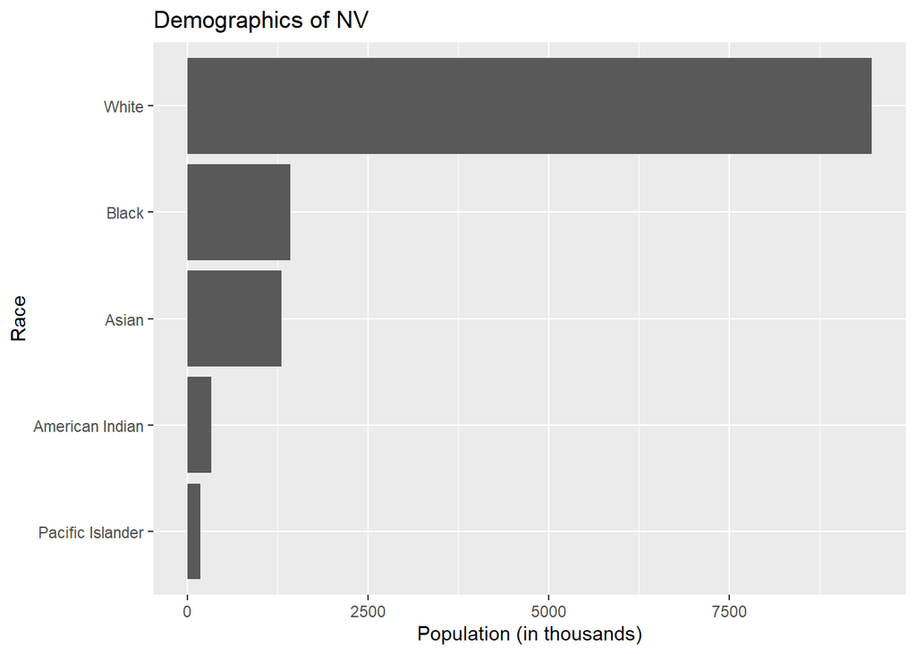

This bar chart shows the race demographics of the state with the lowest ratio of medics to population. This chart was intended to show the relationship between the number of medics and the racial demogrpahics in the state. This chart reveals that there is a sizeable minority population in the state that has the lowest ratio of medics to population.

**Map**: Number of MD in each state

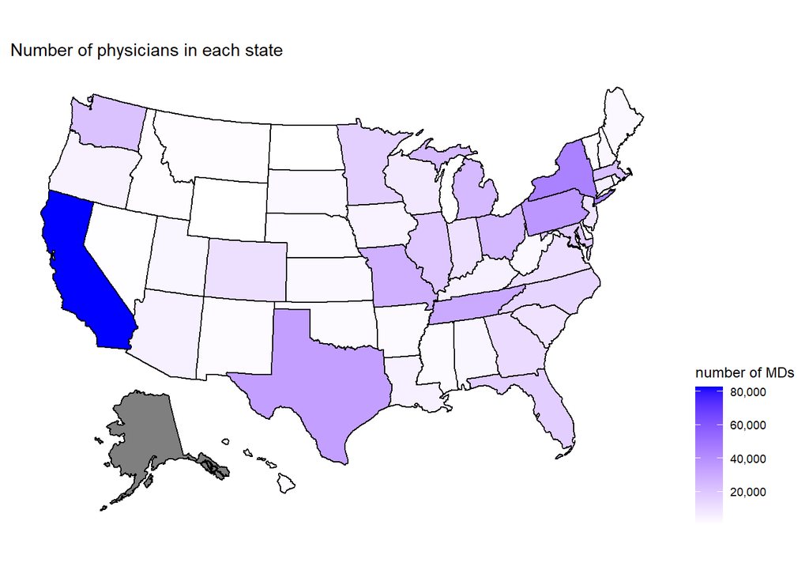

This chart is a density map of the U.S. states shaded by the number of physicians in health systems in each state. States that are shaded with a lighter color have fewer physicians and states that are shaded with a darker blue have more physicians. The chart was intended to visualize how access to healthcare resources (e.g. physicians) varies in different states and across different regions. From this chart, we see that California has the most number of physicians, followed by Northeastern states, such as New York and Pennsylvania. On the other hand, the mountain states, including Wyoming, Nevada, and Idaho, do not have many physicians.

**Scatter Plot**

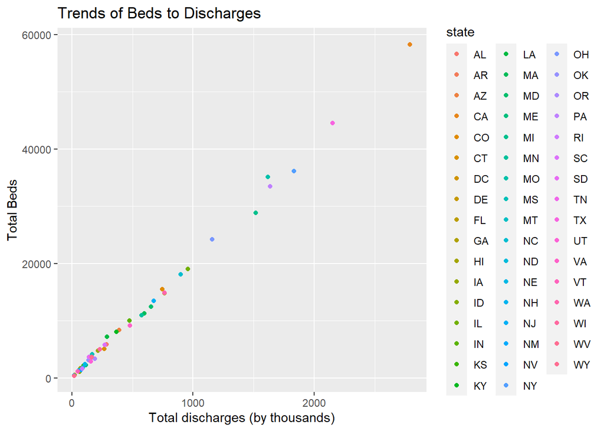

This scatter plot indicates the correlation between the total number of hospital beds to the total number of discharges by state. This evaluates patterns and the number of beds in each state and shows that higher level of bed capacity directly relates to higher number of patient discharges. Grouping each category by state also shows what each state’s average bed capacity to discharge rates as well.